# Terrain Effects

Slope, aspect, and topographic influence

Terrain dramatically influences fire behavior. This tutorial explores slope and aspect effects.

```julia
using Elmfire
using Plots
```

## Slope Effects

Fire spreads faster uphill due to: - Preheating of fuels above the fire - Convective heat transfer - Flame tilting toward uphill fuels

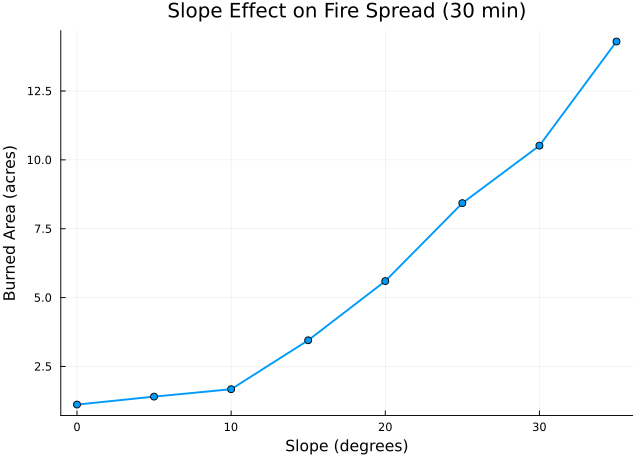

```julia
fuel_table = create_standard_fuel_table(Float64)

slopes = 0:5:35
areas = Float64[]

for slp in slopes
    state = FireState{Float64}(100, 100, 30.0)
    weather = ConstantWeather{Float64}(
        wind_speed_mph = 5.0,
        wind_direction = 180.0,  # From south
        M1 = 0.06, M10 = 0.08, M100 = 0.10,
        MLH = 0.60, MLW = 0.90
    )
    ignite!(state, 50, 50, 0.0)
    # Slope faces south (uphill to north)
    simulate_uniform!(state, 1, fuel_table, weather, Float64(slp), 180.0, 0.0, 30.0)
    push!(areas, get_burned_area_acres(state))
end

plot(slopes, areas,
    xlabel = "Slope (degrees)",
    ylabel = "Burned Area (acres)",
    title = "Slope Effect on Fire Spread (30 min)",
    linewidth = 2,
    marker = :circle,
    legend = false
)
```

### Visualizing Slope Effect

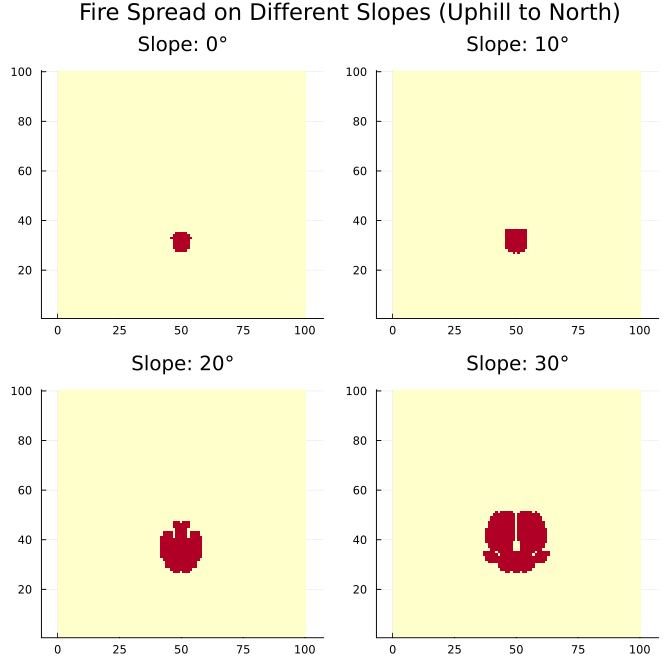

```julia
slopes = [0, 10, 20, 30]
plots = []

for slp in slopes
    state = FireState{Float64}(100, 100, 30.0)
    weather = ConstantWeather{Float64}(
        wind_speed_mph = 5.0,
        wind_direction = 180.0,
        M1 = 0.06, M10 = 0.08, M100 = 0.10,
        MLH = 0.60, MLW = 0.90
    )
    ignite!(state, 50, 30, 0.0)
    simulate_uniform!(state, 1, fuel_table, weather, Float64(slp), 180.0, 0.0, 30.0)

    push!(plots, heatmap(state.burned',
        title = "Slope: $(slp)°",
        color = :YlOrRd,
        aspect_ratio = 1,
        colorbar = false
    ))
end

plot(plots..., layout = (2, 2), size = (700, 700),
    plot_title = "Fire Spread on Different Slopes (Uphill to North)")
```

## Aspect Effects

Aspect is the direction the slope *faces*, so fire runs upslope — toward `aspect - 180`. That means aspect decides whether terrain reinforces the wind or fights it. With wind from the west (blowing east):

- **West-facing** (upslope points east): slope and wind agree, largest fire
- **East-facing** (upslope points west): slope opposes the wind and the two partly cancel, smallest fire
- **North-** and **south-facing**: upslope is perpendicular to the wind, so both give the same area, differing only in which way the fire is pushed off-axis

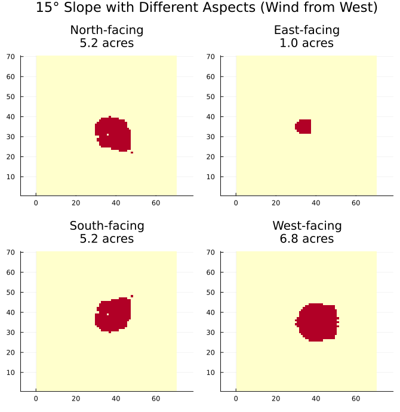

```julia
aspects = [0, 90, 180, 270]
aspect_labels = ["North-facing", "East-facing", "South-facing", "West-facing"]
plots = []

for (asp, lbl) in zip(aspects, aspect_labels)
    state = FireState{Float64}(70, 70, 30.0)
    weather = ConstantWeather{Float64}(
        wind_speed_mph = 5.0,
        wind_direction = 270.0,  # Wind from west
        M1 = 0.06, M10 = 0.08, M100 = 0.10,
        MLH = 0.60, MLW = 0.90
    )
    ignite!(state, 35, 35, 0.0)
    simulate_uniform!(state, 1, fuel_table, weather, 15.0, Float64(asp), 0.0, 60.0)

    acres = round(get_burned_area_acres(state), digits = 1)
    push!(plots, heatmap(state.burned',
        title = "$lbl\n$acres acres",
        color = :YlOrRd,
        aspect_ratio = 1,
        colorbar = false
    ))
end

plot(plots..., layout = (2, 2), size = (700, 720),
    plot_title = "15° Slope with Different Aspects (Wind from West)")
```

The west-facing slope burns roughly seven times the area of the east-facing one under identical wind and fuel — terrain aiding the wind versus opposing it. North- and south-facing come out identical, as the symmetry requires.

## Slope Factor Calculation

The slope factor in the Rothermel model:

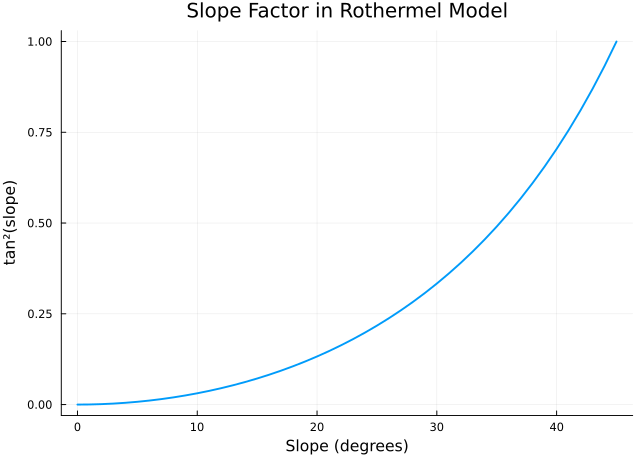

```julia
slopes_deg = 0:1:45
slope_factors = [calculate_tanslp2(Float64(s)) for s in slopes_deg]

plot(slopes_deg, slope_factors,
    xlabel = "Slope (degrees)",
    ylabel = "tan²(slope)",
    title = "Slope Factor in Rothermel Model",
    linewidth = 2,
    legend = false
)
```

## Wind vs Slope Interaction

Wind and slope can reinforce or oppose each other:

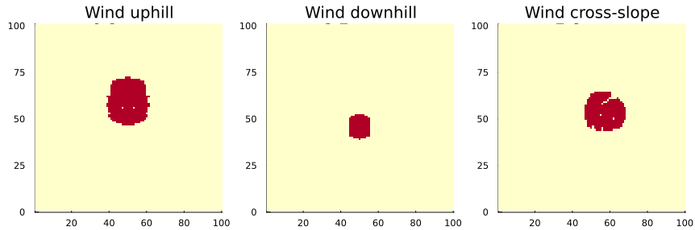

```julia
# Create scenarios
scenarios = [
    ("Wind uphill", 180.0, 180.0),      # Wind from S, slope faces S (uphill N)
    ("Wind downhill", 0.0, 180.0),       # Wind from N, slope faces S (downhill N)
    ("Wind cross-slope", 270.0, 180.0),  # Wind from W, slope faces S
]

plots = []

for (name, wind_dir, aspect) in scenarios
    state = FireState{Float64}(100, 100, 30.0)
    weather = ConstantWeather{Float64}(
        wind_speed_mph = 10.0,
        wind_direction = wind_dir,
        M1 = 0.06, M10 = 0.08, M100 = 0.10,
        MLH = 0.60, MLW = 0.90
    )
    ignite!(state, 50, 50, 0.0)
    simulate_uniform!(state, 1, fuel_table, weather, 20.0, aspect, 0.0, 25.0)

    acres = round(get_burned_area_acres(state), digits=1)
    push!(plots, heatmap(state.burned',
        title = "$name\n$acres acres",
        color = :YlOrRd,
        aspect_ratio = 1,
        colorbar = false
    ))
end

plot(plots..., layout = (1, 3), size = (900, 300))
```

## Complex Terrain

Simulate fire on varying terrain:

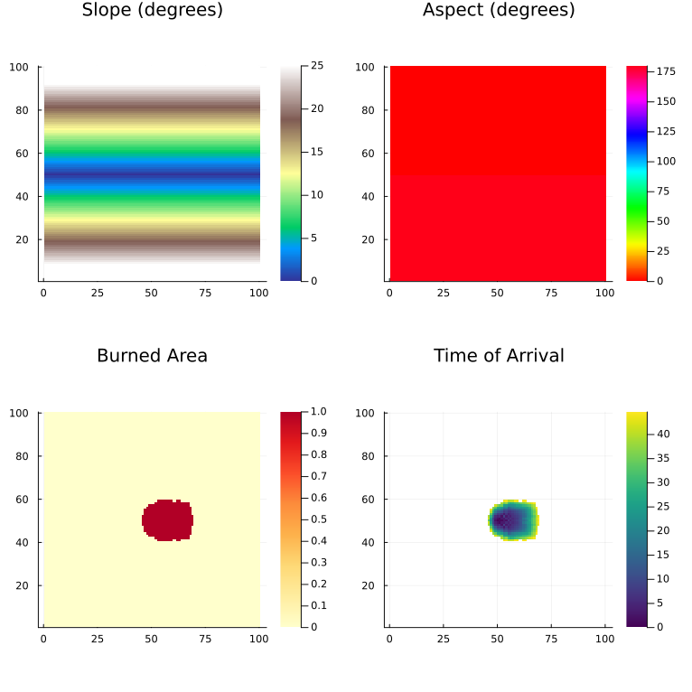

```julia
ncols, nrows = 100, 100
cellsize = 30.0

# Create a simple terrain: valley running E-W
slope = zeros(Float64, ncols, nrows)
aspect = zeros(Float64, ncols, nrows)

for ix in 1:ncols
    for iy in 1:nrows
        dist_from_center = abs(iy - 50)
        slope[ix, iy] = min(25.0, dist_from_center * 0.6)
        aspect[ix, iy] = iy < 50 ? 180.0 : 0.0  # South-facing above, North-facing below
    end
end

state = FireState{Float64}(ncols, nrows, cellsize)
fuel_ids = fill(1, ncols, nrows)
weather = ConstantWeather{Float64}(
    wind_speed_mph = 8.0,
    wind_direction = 270.0,
    M1 = 0.06, M10 = 0.08, M100 = 0.10,
    MLH = 0.60, MLW = 0.90
)

ignite!(state, 50, 50, 0.0)  # Ignite at valley bottom
simulate!(state, fuel_ids, fuel_table, weather, slope, aspect, 0.0, 45.0)

p1 = heatmap(slope', title = "Slope (degrees)", color = :terrain, aspect_ratio = 1)
p2 = heatmap(aspect', title = "Aspect (degrees)", color = :hsv, aspect_ratio = 1)
p3 = heatmap(state.burned', title = "Burned Area", color = :YlOrRd, aspect_ratio = 1)

toa = copy(state.time_of_arrival)
toa[toa .< 0] .= NaN
p4 = heatmap(toa', title = "Time of Arrival", color = :viridis, aspect_ratio = 1)

plot(p1, p2, p3, p4, layout = (2, 2), size = (800, 800))
```

## Ridge and Valley Effects

Fire behavior changes dramatically at terrain features. Igniting west of a N-S ridge, with wind from the west, puts slope and wind in agreement on the windward flank and in opposition on the lee side:

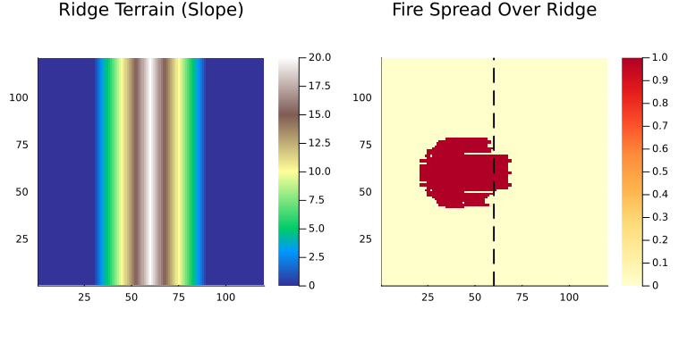

```julia
# Create terrain with ridge
ncols, nrows = 120, 120
slope = zeros(Float64, ncols, nrows)
aspect = zeros(Float64, ncols, nrows)

# Ridge running N-S at x=60
for ix in 1:ncols
    for iy in 1:nrows
        dist = abs(ix - 60)
        if dist < 30
            slope[ix, iy] = 20.0 * (1 - dist/30)
            # Aspect is the downhill direction. West of the crest the ground rises
            # toward the east, so it faces west (270°); east of the crest it faces
            # east (90°).
            aspect[ix, iy] = ix < 60 ? 270.0 : 90.0
        end
    end
end

state = FireState{Float64}(ncols, nrows, 30.0)
fuel_ids = fill(1, ncols, nrows)
weather = ConstantWeather{Float64}(
    wind_speed_mph = 15.0,
    wind_direction = 270.0,  # From west
    M1 = 0.05, M10 = 0.07, M100 = 0.09,
    MLH = 0.55, MLW = 0.85
)

ignite!(state, 30, 60, 0.0)  # Ignite west of ridge
simulate!(state, fuel_ids, fuel_table, weather, slope, aspect, 0.0, 90.0)

p1 = heatmap(slope', title = "Ridge Terrain (Slope)", color = :terrain, aspect_ratio = 1)
p2 = heatmap(state.burned', title = "Fire Spread Over Ridge", color = :YlOrRd, aspect_ratio = 1)
vline!(p2, [60], color = :black, linestyle = :dash, linewidth = 2, label = "")

plot(p1, p2, layout = (1, 2), size = (800, 400))
```

Fire accelerates up the windward slope and may slow on the lee side.

## Steep Terrain Considerations

On very steep slopes (>30°), fire behavior can become extreme:

```
Maximum fireline intensity: 54349.0 kW/m
EXTREME fire behavior - spotting likely, aerial suppression ineffective
```

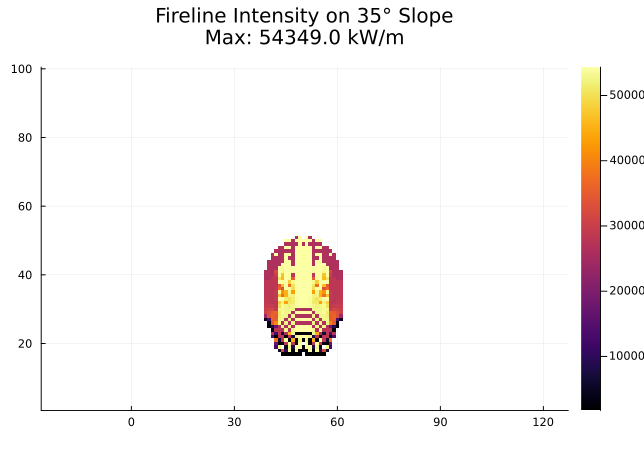

```julia
# Extreme slope scenario
state = FireState{Float64}(100, 100, 30.0)
weather = ConstantWeather{Float64}(
    wind_speed_mph = 15.0,
    wind_direction = 180.0,  # From south (uphill)
    M1 = 0.04, M10 = 0.06, M100 = 0.08,
    MLH = 0.40, MLW = 0.70
)

ignite!(state, 50, 20, 0.0)
simulate_uniform!(state, 4, fuel_table, weather, 35.0, 180.0, 0.0, 20.0)

# Check fireline intensity
max_flin = maximum(state.fireline_intensity)
println("Maximum fireline intensity: $(round(max_flin, digits=0)) kW/m")

# Classify intensity
if max_flin > 10000
    println("EXTREME fire behavior - spotting likely, aerial suppression ineffective")
elseif max_flin > 4000
    println("VERY HIGH intensity - indirect attack recommended")
elseif max_flin > 2000
    println("HIGH intensity - mechanical equipment needed")
else
    println("MODERATE intensity - direct attack possible")
end

flin = copy(state.fireline_intensity)
flin[flin .== 0] .= NaN

heatmap(flin',
    title = "Fireline Intensity on 35° Slope\nMax: $(round(max_flin, digits=0)) kW/m",
    color = :inferno,
    aspect_ratio = 1
)
```